# Optimal Treatment Analysis

## Outcome Variable

**Outcome Variable:** whz

## Predictor Variables

**Intervention Variable:** safeh20

**Adjustment Set:**

- arm
- sex
- W_mage
- meducyrs
- feducyrs
- hhwealth_quart
- hfoodsec
- W_mhtcm
- W_nrooms
- W_nchldlt5
- W_parity
- impfloor
- impsan
- delta_W_mage
- delta_meducyrs
- delta_feducyrs
- delta_hhwealth_quart
- delta_hfoodsec
- delta_W_mhtcm
- delta_W_nrooms
- delta_W_nchldlt5
- delta_W_parity
- delta_impfloor
- delta_impsan

## Stratifying Variables

The analysis was stratified on these variable(s):

- agecat
- studyid
- country

## Data Summary

| agecat | studyid | country | safeh20 | n_cell | n |
| --- | --- | --- | --- | --- | --- |
| Birth | ki0047075b-MAL-ED | BANGLADESH | 1 | 0 | 222 |
| Birth | ki0047075b-MAL-ED | BANGLADESH | 0 | 222 | 222 |
| Birth | ki0047075b-MAL-ED | BRAZIL | 1 | 0 | 119 |
| Birth | ki0047075b-MAL-ED | BRAZIL | 0 | 119 | 119 |
| Birth | ki0047075b-MAL-ED | INDIA | 1 | 0 | 188 |
| Birth | ki0047075b-MAL-ED | INDIA | 0 | 188 | 188 |
| Birth | ki0047075b-MAL-ED | NEPAL | 1 | 1 | 164 |
| Birth | ki0047075b-MAL-ED | NEPAL | 0 | 163 | 164 |
| Birth | ki0047075b-MAL-ED | PERU | 1 | 9 | 240 |
| Birth | ki0047075b-MAL-ED | PERU | 0 | 231 | 240 |
| Birth | ki0047075b-MAL-ED | SOUTH AFRICA | 1 | 33 | 214 |
| Birth | ki0047075b-MAL-ED | SOUTH AFRICA | 0 | 181 | 214 |
| Birth | ki0047075b-MAL-ED | TANZANIA, UNITED REPUBLIC OF | 1 | 76 | 114 |
| Birth | ki0047075b-MAL-ED | TANZANIA, UNITED REPUBLIC OF | 0 | 38 | 114 |
| Birth | ki1017093-NIH-Birth | BANGLADESH | 1 | 28 | 28 |
| Birth | ki1017093-NIH-Birth | BANGLADESH | 0 | 0 | 28 |
| Birth | ki1017093c-NIH-Crypto | BANGLADESH | 1 | 23 | 23 |
| Birth | ki1017093c-NIH-Crypto | BANGLADESH | 0 | 0 | 23 |
| Birth | kiGH5241-JiVitA-3 | BANGLADESH | 1 | 15666 | 15690 |
| Birth | kiGH5241-JiVitA-3 | BANGLADESH | 0 | 24 | 15690 |
| Birth | kiGH5241-JiVitA-4 | BANGLADESH | 1 | 683 | 683 |
| Birth | kiGH5241-JiVitA-4 | BANGLADESH | 0 | 0 | 683 |
| 6 months | ki0047075b-MAL-ED | BANGLADESH | 1 | 0 | 240 |
| 6 months | ki0047075b-MAL-ED | BANGLADESH | 0 | 240 | 240 |
| 6 months | ki0047075b-MAL-ED | BRAZIL | 1 | 0 | 142 |
| 6 months | ki0047075b-MAL-ED | BRAZIL | 0 | 142 | 142 |
| 6 months | ki0047075b-MAL-ED | INDIA | 1 | 0 | 235 |
| 6 months | ki0047075b-MAL-ED | INDIA | 0 | 235 | 235 |
| 6 months | ki0047075b-MAL-ED | NEPAL | 1 | 1 | 233 |
| 6 months | ki0047075b-MAL-ED | NEPAL | 0 | 232 | 233 |
| 6 months | ki0047075b-MAL-ED | PERU | 1 | 11 | 259 |
| 6 months | ki0047075b-MAL-ED | PERU | 0 | 248 | 259 |
| 6 months | ki0047075b-MAL-ED | SOUTH AFRICA | 1 | 37 | 248 |
| 6 months | ki0047075b-MAL-ED | SOUTH AFRICA | 0 | 211 | 248 |
| 6 months | ki0047075b-MAL-ED | TANZANIA, UNITED REPUBLIC OF | 1 | 168 | 246 |
| 6 months | ki0047075b-MAL-ED | TANZANIA, UNITED REPUBLIC OF | 0 | 78 | 246 |
| 6 months | ki1000304b-SAS-FoodSuppl | INDIA | 1 | 380 | 380 |
| 6 months | ki1000304b-SAS-FoodSuppl | INDIA | 0 | 0 | 380 |
| 6 months | ki1017093-NIH-Birth | BANGLADESH | 1 | 534 | 536 |
| 6 months | ki1017093-NIH-Birth | BANGLADESH | 0 | 2 | 536 |
| 6 months | ki1017093b-PROVIDE | BANGLADESH | 1 | 580 | 580 |
| 6 months | ki1017093b-PROVIDE | BANGLADESH | 0 | 0 | 580 |
| 6 months | ki1017093c-NIH-Crypto | BANGLADESH | 1 | 715 | 715 |
| 6 months | ki1017093c-NIH-Crypto | BANGLADESH | 0 | 0 | 715 |
| 6 months | ki1114097-CONTENT | PERU | 1 | 54 | 57 |
| 6 months | ki1114097-CONTENT | PERU | 0 | 3 | 57 |
| 6 months | ki1148112-LCNI-5 | MALAWI | 1 | 672 | 816 |
| 6 months | ki1148112-LCNI-5 | MALAWI | 0 | 144 | 816 |
| 6 months | kiGH5241-JiVitA-3 | BANGLADESH | 1 | 16756 | 16776 |
| 6 months | kiGH5241-JiVitA-3 | BANGLADESH | 0 | 20 | 16776 |
| 6 months | kiGH5241-JiVitA-4 | BANGLADESH | 1 | 4826 | 4827 |
| 6 months | kiGH5241-JiVitA-4 | BANGLADESH | 0 | 1 | 4827 |
| 24 months | ki0047075b-MAL-ED | BANGLADESH | 1 | 0 | 212 |
| 24 months | ki0047075b-MAL-ED | BANGLADESH | 0 | 212 | 212 |
| 24 months | ki0047075b-MAL-ED | BRAZIL | 1 | 0 | 113 |
| 24 months | ki0047075b-MAL-ED | BRAZIL | 0 | 113 | 113 |
| 24 months | ki0047075b-MAL-ED | INDIA | 1 | 0 | 227 |
| 24 months | ki0047075b-MAL-ED | INDIA | 0 | 227 | 227 |
| 24 months | ki0047075b-MAL-ED | NEPAL | 1 | 1 | 226 |
| 24 months | ki0047075b-MAL-ED | NEPAL | 0 | 225 | 226 |
| 24 months | ki0047075b-MAL-ED | PERU | 1 | 7 | 193 |
| 24 months | ki0047075b-MAL-ED | PERU | 0 | 186 | 193 |
| 24 months | ki0047075b-MAL-ED | SOUTH AFRICA | 1 | 34 | 237 |
| 24 months | ki0047075b-MAL-ED | SOUTH AFRICA | 0 | 203 | 237 |
| 24 months | ki0047075b-MAL-ED | TANZANIA, UNITED REPUBLIC OF | 1 | 145 | 213 |
| 24 months | ki0047075b-MAL-ED | TANZANIA, UNITED REPUBLIC OF | 0 | 68 | 213 |
| 24 months | ki1017093-NIH-Birth | BANGLADESH | 1 | 426 | 428 |
| 24 months | ki1017093-NIH-Birth | BANGLADESH | 0 | 2 | 428 |
| 24 months | ki1017093b-PROVIDE | BANGLADESH | 1 | 577 | 577 |
| 24 months | ki1017093b-PROVIDE | BANGLADESH | 0 | 0 | 577 |
| 24 months | ki1017093c-NIH-Crypto | BANGLADESH | 1 | 514 | 514 |
| 24 months | ki1017093c-NIH-Crypto | BANGLADESH | 0 | 0 | 514 |
| 24 months | ki1114097-CONTENT | PERU | 1 | 45 | 48 |
| 24 months | ki1114097-CONTENT | PERU | 0 | 3 | 48 |
| 24 months | ki1148112-LCNI-5 | MALAWI | 1 | 464 | 558 |
| 24 months | ki1148112-LCNI-5 | MALAWI | 0 | 94 | 558 |
| 24 months | kiGH5241-JiVitA-3 | BANGLADESH | 1 | 8583 | 8594 |
| 24 months | kiGH5241-JiVitA-3 | BANGLADESH | 0 | 11 | 8594 |
| 24 months | kiGH5241-JiVitA-4 | BANGLADESH | 1 | 4729 | 4730 |
| 24 months | kiGH5241-JiVitA-4 | BANGLADESH | 0 | 1 | 4730 |

The following strata were considered:

- agecat: 24 months, studyid: ki0047075b-MAL-ED, country: BANGLADESH
- agecat: 24 months, studyid: ki0047075b-MAL-ED, country: BRAZIL
- agecat: 24 months, studyid: ki0047075b-MAL-ED, country: INDIA
- agecat: 24 months, studyid: ki0047075b-MAL-ED, country: NEPAL
- agecat: 24 months, studyid: ki0047075b-MAL-ED, country: PERU
- agecat: 24 months, studyid: ki0047075b-MAL-ED, country: SOUTH AFRICA
- agecat: 24 months, studyid: ki0047075b-MAL-ED, country: TANZANIA, UNITED REPUBLIC OF
- agecat: 24 months, studyid: ki1017093-NIH-Birth, country: BANGLADESH
- agecat: 24 months, studyid: ki1017093b-PROVIDE, country: BANGLADESH
- agecat: 24 months, studyid: ki1017093c-NIH-Crypto, country: BANGLADESH
- agecat: 24 months, studyid: ki1114097-CONTENT, country: PERU
- agecat: 24 months, studyid: ki1148112-LCNI-5, country: MALAWI
- agecat: 24 months, studyid: kiGH5241-JiVitA-3, country: BANGLADESH
- agecat: 24 months, studyid: kiGH5241-JiVitA-4, country: BANGLADESH
- agecat: 6 months, studyid: ki0047075b-MAL-ED, country: BANGLADESH
- agecat: 6 months, studyid: ki0047075b-MAL-ED, country: BRAZIL
- agecat: 6 months, studyid: ki0047075b-MAL-ED, country: INDIA
- agecat: 6 months, studyid: ki0047075b-MAL-ED, country: NEPAL
- agecat: 6 months, studyid: ki0047075b-MAL-ED, country: PERU
- agecat: 6 months, studyid: ki0047075b-MAL-ED, country: SOUTH AFRICA
- agecat: 6 months, studyid: ki0047075b-MAL-ED, country: TANZANIA, UNITED REPUBLIC OF
- agecat: 6 months, studyid: ki1000304b-SAS-FoodSuppl, country: INDIA
- agecat: 6 months, studyid: ki1017093-NIH-Birth, country: BANGLADESH
- agecat: 6 months, studyid: ki1017093b-PROVIDE, country: BANGLADESH
- agecat: 6 months, studyid: ki1017093c-NIH-Crypto, country: BANGLADESH
- agecat: 6 months, studyid: ki1114097-CONTENT, country: PERU
- agecat: 6 months, studyid: ki1148112-LCNI-5, country: MALAWI
- agecat: 6 months, studyid: kiGH5241-JiVitA-3, country: BANGLADESH
- agecat: 6 months, studyid: kiGH5241-JiVitA-4, country: BANGLADESH
- agecat: Birth, studyid: ki0047075b-MAL-ED, country: BANGLADESH
- agecat: Birth, studyid: ki0047075b-MAL-ED, country: BRAZIL
- agecat: Birth, studyid: ki0047075b-MAL-ED, country: INDIA
- agecat: Birth, studyid: ki0047075b-MAL-ED, country: NEPAL
- agecat: Birth, studyid: ki0047075b-MAL-ED, country: PERU
- agecat: Birth, studyid: ki0047075b-MAL-ED, country: SOUTH AFRICA
- agecat: Birth, studyid: ki0047075b-MAL-ED, country: TANZANIA, UNITED REPUBLIC OF
- agecat: Birth, studyid: ki1017093-NIH-Birth, country: BANGLADESH
- agecat: Birth, studyid: ki1017093c-NIH-Crypto, country: BANGLADESH
- agecat: Birth, studyid: kiGH5241-JiVitA-3, country: BANGLADESH
- agecat: Birth, studyid: kiGH5241-JiVitA-4, country: BANGLADESH

### Dropped Strata

Some strata were dropped due to rare outcomes:

- agecat: Birth, studyid: ki0047075b-MAL-ED, country: BANGLADESH
- agecat: Birth, studyid: ki0047075b-MAL-ED, country: BRAZIL
- agecat: Birth, studyid: ki0047075b-MAL-ED, country: INDIA
- agecat: Birth, studyid: ki0047075b-MAL-ED, country: NEPAL
- agecat: Birth, studyid: ki1017093-NIH-Birth, country: BANGLADESH
- agecat: Birth, studyid: ki1017093c-NIH-Crypto, country: BANGLADESH
- agecat: Birth, studyid: kiGH5241-JiVitA-4, country: BANGLADESH
- agecat: 6 months, studyid: ki0047075b-MAL-ED, country: BANGLADESH
- agecat: 6 months, studyid: ki0047075b-MAL-ED, country: BRAZIL
- agecat: 6 months, studyid: ki0047075b-MAL-ED, country: INDIA
- agecat: 6 months, studyid: ki0047075b-MAL-ED, country: NEPAL
- agecat: 6 months, studyid: ki1000304b-SAS-FoodSuppl, country: INDIA
- agecat: 6 months, studyid: ki1017093-NIH-Birth, country: BANGLADESH
- agecat: 6 months, studyid: ki1017093b-PROVIDE, country: BANGLADESH
- agecat: 6 months, studyid: ki1017093c-NIH-Crypto, country: BANGLADESH
- agecat: 6 months, studyid: ki1114097-CONTENT, country: PERU
- agecat: 6 months, studyid: kiGH5241-JiVitA-4, country: BANGLADESH
- agecat: 24 months, studyid: ki0047075b-MAL-ED, country: BANGLADESH
- agecat: 24 months, studyid: ki0047075b-MAL-ED, country: BRAZIL
- agecat: 24 months, studyid: ki0047075b-MAL-ED, country: INDIA
- agecat: 24 months, studyid: ki0047075b-MAL-ED, country: NEPAL
- agecat: 24 months, studyid: ki1017093-NIH-Birth, country: BANGLADESH
- agecat: 24 months, studyid: ki1017093b-PROVIDE, country: BANGLADESH
- agecat: 24 months, studyid: ki1017093c-NIH-Crypto, country: BANGLADESH
- agecat: 24 months, studyid: ki1114097-CONTENT, country: PERU
- agecat: 24 months, studyid: kiGH5241-JiVitA-4, country: BANGLADESH

## Methods Detail

We’re interested in the causal parameters $E[Y_a]$ for all values of $a \in \mathcal{A}$. These parameters represent the mean outcome if, possibly contrary to fact, we intervened to set all units to have $A=a$. Under the randomization and positivity assumptions, these are identified by the statistical parameters $\psi_a=E_W[E_{Y|A,W}(Y|A=a,W)]$. In addition, we’re interested in the mean of $Y$, $E[Y]$ under no intervention (the observed mean). We will estimate these parameters by using SuperLearner to fit the relevant likelihood factors – $E_{Y|A,W}(Y|A=a,W)$ and $p(A=a|W)$, and then updating our likelihood fit using a joint TMLE.

For unadjusted analyses ($W=\{\}$), initial likelihoods were estimated using Lrnr_glm to estimate the simple $E(Y|A)$ and Lrnr_mean to estimate $p(A)$. For adjusted analyses, a small library containing Lrnr_glmnet, Lrnr_xgboost, and Lrnr_mean was used.

Having estimated these parameters, we will then use the delta method to estimate relative risks and attributable risks relative to a prespecified baseline level of $A$.

# Results Detail

## Results Plots

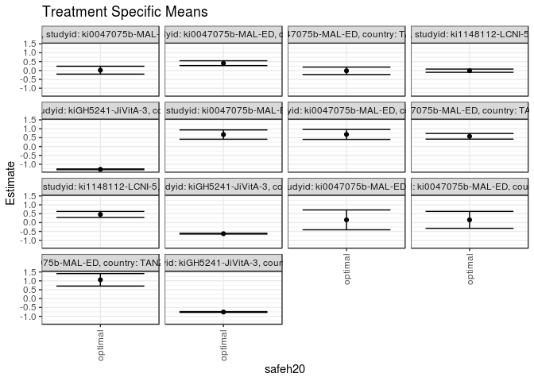

## Results Table

### Parameter: TSM

| agecat | studyid | country | intervention_level | baseline_level | estimate | ci_lower | ci_upper |
| --- | --- | --- | --- | --- | --- | --- | --- |
| Birth | ki0047075b-MAL-ED | PERU | optimal | observed | 0.1517399 | -0.4066776 | 0.7101574 |
| Birth | ki0047075b-MAL-ED | SOUTH AFRICA | optimal | observed | 0.1523950 | -0.3238340 | 0.6286240 |
| Birth | ki0047075b-MAL-ED | TANZANIA, UNITED REPUBLIC OF | optimal | observed | 1.0557273 | 0.7048608 | 1.4065937 |
| Birth | kiGH5241-JiVitA-3 | BANGLADESH | optimal | observed | -0.7548262 | -0.7765576 | -0.7330948 |
| 6 months | ki0047075b-MAL-ED | PERU | optimal | observed | 0.6735425 | 0.4111873 | 0.9358977 |
| 6 months | ki0047075b-MAL-ED | SOUTH AFRICA | optimal | observed | 0.6821216 | 0.4024635 | 0.9617797 |
| 6 months | ki0047075b-MAL-ED | TANZANIA, UNITED REPUBLIC OF | optimal | observed | 0.5757117 | 0.4169643 | 0.7344591 |
| 6 months | ki1148112-LCNI-5 | MALAWI | optimal | observed | 0.4583594 | 0.2895253 | 0.6271936 |
| 6 months | kiGH5241-JiVitA-3 | BANGLADESH | optimal | observed | -0.6268591 | -0.6483898 | -0.6053283 |
| 24 months | ki0047075b-MAL-ED | PERU | optimal | observed | 0.0168406 | -0.2052018 | 0.2388829 |
| 24 months | ki0047075b-MAL-ED | SOUTH AFRICA | optimal | observed | 0.4108515 | 0.2746400 | 0.5470630 |
| 24 months | ki0047075b-MAL-ED | TANZANIA, UNITED REPUBLIC OF | optimal | observed | -0.0177974 | -0.2292557 | 0.1936608 |
| 24 months | ki1148112-LCNI-5 | MALAWI | optimal | observed | -0.0112649 | -0.1014870 | 0.0789573 |
| 24 months | kiGH5241-JiVitA-3 | BANGLADESH | optimal | observed | -1.2842669 | -1.3070308 | -1.2615030 |

### Parameter: E(Y)

| agecat | studyid | country | intervention_level | baseline_level | estimate | ci_lower | ci_upper |
| --- | --- | --- | --- | --- | --- | --- | --- |
| Birth | ki0047075b-MAL-ED | PERU | observed | observed | -0.0384167 | -0.1584416 | 0.0816083 |
| Birth | ki0047075b-MAL-ED | SOUTH AFRICA | observed | observed | -0.0034112 | -0.1591733 | 0.1523508 |
| Birth | ki0047075b-MAL-ED | TANZANIA, UNITED REPUBLIC OF | observed | observed | 0.8024561 | 0.5990025 | 1.0059098 |
| Birth | kiGH5241-JiVitA-3 | BANGLADESH | observed | observed | -0.7239267 | -0.7437724 | -0.7040810 |
| 6 months | ki0047075b-MAL-ED | PERU | observed | observed | 1.0507722 | 0.9245302 | 1.1770142 |
| 6 months | ki0047075b-MAL-ED | SOUTH AFRICA | observed | observed | 0.5429099 | 0.3886447 | 0.6971752 |
| 6 months | ki0047075b-MAL-ED | TANZANIA, UNITED REPUBLIC OF | observed | observed | 0.5165515 | 0.3861929 | 0.6469101 |
| 6 months | ki1148112-LCNI-5 | MALAWI | observed | observed | 0.4418137 | 0.3703100 | 0.5133174 |
| 6 months | kiGH5241-JiVitA-3 | BANGLADESH | observed | observed | -0.5932502 | -0.6127743 | -0.5737261 |
| 24 months | ki0047075b-MAL-ED | PERU | observed | observed | 0.1061658 | -0.0166496 | 0.2289812 |
| 24 months | ki0047075b-MAL-ED | SOUTH AFRICA | observed | observed | 0.4231857 | 0.3036551 | 0.5427162 |
| 24 months | ki0047075b-MAL-ED | TANZANIA, UNITED REPUBLIC OF | observed | observed | 0.0470892 | -0.0782759 | 0.1724543 |
| 24 months | ki1148112-LCNI-5 | MALAWI | observed | observed | -0.0478674 | -0.1301904 | 0.0344557 |
| 24 months | kiGH5241-JiVitA-3 | BANGLADESH | observed | observed | -1.2973086 | -1.3206115 | -1.2740057 |

### Parameter: PAR

| agecat | studyid | country | intervention_level | baseline_level | estimate | ci_lower | ci_upper |
| --- | --- | --- | --- | --- | --- | --- | --- |
| Birth | ki0047075b-MAL-ED | PERU | optimal | observed | -0.1901566 | -0.7439889 | 0.3636757 |
| Birth | ki0047075b-MAL-ED | SOUTH AFRICA | optimal | observed | -0.1558062 | -0.5851702 | 0.2735577 |
| Birth | ki0047075b-MAL-ED | TANZANIA, UNITED REPUBLIC OF | optimal | observed | -0.2532711 | -0.5453617 | 0.0388195 |
| Birth | kiGH5241-JiVitA-3 | BANGLADESH | optimal | observed | 0.0308995 | 0.0216883 | 0.0401107 |
| 6 months | ki0047075b-MAL-ED | PERU | optimal | observed | 0.3772297 | 0.1260065 | 0.6284528 |
| 6 months | ki0047075b-MAL-ED | SOUTH AFRICA | optimal | observed | -0.1392117 | -0.3723016 | 0.0938783 |
| 6 months | ki0047075b-MAL-ED | TANZANIA, UNITED REPUBLIC OF | optimal | observed | -0.0591602 | -0.1485610 | 0.0302406 |
| 6 months | ki1148112-LCNI-5 | MALAWI | optimal | observed | -0.0165457 | -0.1613520 | 0.1282606 |
| 6 months | kiGH5241-JiVitA-3 | BANGLADESH | optimal | observed | 0.0336089 | 0.0239099 | 0.0433078 |
| 24 months | ki0047075b-MAL-ED | PERU | optimal | observed | 0.0893252 | -0.0928757 | 0.2715261 |
| 24 months | ki0047075b-MAL-ED | SOUTH AFRICA | optimal | observed | 0.0123341 | -0.0574195 | 0.0820878 |
| 24 months | ki0047075b-MAL-ED | TANZANIA, UNITED REPUBLIC OF | optimal | observed | 0.0648866 | -0.1039101 | 0.2336834 |
| 24 months | ki1148112-LCNI-5 | MALAWI | optimal | observed | -0.0366025 | -0.0733745 | 0.0001694 |
| 24 months | kiGH5241-JiVitA-3 | BANGLADESH | optimal | observed | -0.0130417 | -0.0205828 | -0.0055006 |